# CyclisticUsage

Arvilla

12/20/2021

## Task

What we have here is the previous 12 months of Cyclistic usage data. Cyclistic is a bike-share offering composed of a fleet of 5,824 geotracked bicycles with a network of 692 stations across Chicago.

We have been asked to analyze historical bike trip data to identify trends. The main three questions we’re looking at in order to inform future marketing are: *How do annual members and casual riders use the bikes differently?* Why would casual riders buy annual memberships? *How can Cyclistic use digital media to influence casual riders to become members?

Today, we’re looking specifically at the first question.

##Preparing the data

The 12 months of trip data were provided in 12 separate csv files.

Packages used:

```r
library(tidyverse)
library(lubridate)
```

```r
library(ggplot2)
library(dplyr)
```

Set working directory:

```r
setwd("/Users/arvillam/Downloads/Capstone/csv")
```

Collect data:

```r
Dec2020 <- read_csv("202012-divvy-tripdata.csv")
Jan2021 <- read_csv("202101-divvy-tripdata.csv")
Feb2021 <- read_csv("202102-divvy-tripdata.csv")
Mar2021 <- read_csv("202103-divvy-tripdata.csv")
Apr2021 <- read_csv("202104-divvy-tripdata.csv")
May2021 <- read_csv("202105-divvy-tripdata.csv")
Jun2021 <- read_csv("202106-divvy-tripdata.csv")
Jul2021 <- read_csv("202107-divvy-tripdata.csv")
Aug2021 <- read_csv("202108-divvy-tripdata.csv")
Sep2021 <- read_csv("202109-divvy-tripdata.csv")
Oct2021 <- read_csv("202110-divvy-tripdata.csv")
Nov2021 <- read_csv("202111-divvy-tripdata.csv")
```

We note that they all have 13 columns, 7 of which are characters, 4 are numeric, and 2 are dates.

We check that colnames match.

```r
colnames(Dec2020)
```

```
##  [1] "ride_id"            "rideable_type"      "started_at"
##  [4] "ended_at"           "start_station_name" "start_station_id"
##  [7] "end_station_name"   "end_station_id"     "start_lat"
## [10] "start_lng"          "end_lat"            "end_lng"
## [13] "member_casual"
```

```r
colnames(Jan2021)
```

```
##  [1] "ride_id"            "rideable_type"      "started_at"
##  [4] "ended_at"           "start_station_name" "start_station_id"
##  [7] "end_station_name"   "end_station_id"     "start_lat"
## [10] "start_lng"          "end_lat"            "end_lng"
## [13] "member_casual"
```

```r
colnames(Feb2021)
```

```
##  [1] "ride_id"            "rideable_type"      "started_at"
##  [4] "ended_at"           "start_station_name" "start_station_id"
##  [7] "end_station_name"   "end_station_id"     "start_lat"
## [10] "start_lng"          "end_lat"            "end_lng"
## [13] "member_casual"
```

```r
colnames(Mar2021)
```

```
##  [1] "ride_id"            "rideable_type"      "started_at"
##  [4] "ended_at"           "start_station_name" "start_station_id"
##  [7] "end_station_name"   "end_station_id"     "start_lat"
## [10] "start_lng"          "end_lat"            "end_lng"
## [13] "member_casual"
```

```r
colnames(Apr2021)
```

```
##  [1] "ride_id"            "rideable_type"      "started_at"
##  [4] "ended_at"           "start_station_name" "start_station_id"
##  [7] "end_station_name"   "end_station_id"     "start_lat"
## [10] "start_lng"          "end_lat"            "end_lng"
## [13] "member_casual"
```

```r
colnames(May2021)
```

```
##  [1] "ride_id"            "rideable_type"      "started_at"
##  [4] "ended_at"           "start_station_name" "start_station_id"
##  [7] "end_station_name"   "end_station_id"     "start_lat"
## [10] "start_lng"          "end_lat"            "end_lng"
## [13] "member_casual"
```

```r
colnames(Jun2021)
```

```
##  [1] "ride_id"            "rideable_type"      "started_at"
##  [4] "ended_at"           "start_station_name" "start_station_id"
##  [7] "end_station_name"   "end_station_id"     "start_lat"
## [10] "start_lng"          "end_lat"            "end_lng"
## [13] "member_casual"
```

```r
colnames(Jul2021)
```

```
##  [1] "ride_id"            "rideable_type"      "started_at"
##  [4] "ended_at"           "start_station_name" "start_station_id"
##  [7] "end_station_name"   "end_station_id"     "start_lat"
## [10] "start_lng"          "end_lat"            "end_lng"
## [13] "member_casual"
```

```r
colnames(Aug2021)
```

```
##  [1] "ride_id"            "rideable_type"      "started_at"
##  [4] "ended_at"           "start_station_name" "start_station_id"
##  [7] "end_station_name"   "end_station_id"     "start_lat"
## [10] "start_lng"          "end_lat"            "end_lng"
## [13] "member_casual"
```

```r
colnames(Sep2021)
```

```
##  [1] "ride_id"            "rideable_type"      "started_at"
##  [4] "ended_at"           "start_station_name" "start_station_id"
##  [7] "end_station_name"   "end_station_id"     "start_lat"
## [10] "start_lng"          "end_lat"            "end_lng"
## [13] "member_casual"
```

```r
colnames(Oct2021)
```

```
##  [1] "ride_id"            "rideable_type"      "started_at"
##  [4] "ended_at"           "start_station_name" "start_station_id"
##  [7] "end_station_name"   "end_station_id"     "start_lat"
## [10] "start_lng"          "end_lat"            "end_lng"
## [13] "member_casual"
```

```r
colnames(Nov2021)
```

```
##  [1] "ride_id"            "rideable_type"      "started_at"
##  [4] "ended_at"           "start_station_name" "start_station_id"
##  [7] "end_station_name"   "end_station_id"     "start_lat"
## [10] "start_lng"          "end_lat"            "end_lng"
## [13] "member_casual"
```

We checked that the dates are reasonable for their sheets.

```r
min(Dec2020$started_at)
```

```
## [1] "2020-12-01 00:01:15 UTC"
```

```r
max(Dec2020$started_at)
```

```
## [1] "2020-12-31 23:59:59 UTC"
```

```r
min(Jan2021$started_at)
```

```
## [1] "2021-01-01 00:02:05 UTC"
```

```r
max(Jan2021$started_at)
```

```
## [1] "2021-01-31 23:57:00 UTC"
```

```r
min(Feb2021$started_at)
```

```
## [1] "2021-02-01 00:55:44 UTC"
```

```r
max(Feb2021$started_at)
```

```
## [1] "2021-02-28 23:59:41 UTC"
```

```r
min(Mar2021$started_at)
```

```
## [1] "2021-03-01 00:01:09 UTC"
```

```r
max(Mar2021$started_at)
```

```
## [1] "2021-03-31 23:59:08 UTC"
```

```r
min(Apr2021$started_at)
```

```
## [1] "2021-04-01 00:03:18 UTC"
```

```r
max(Apr2021$started_at)
```

```
## [1] "2021-04-30 23:59:53 UTC"
```

```r
min(May2021$started_at)
```

```
## [1] "2021-05-01 00:00:11 UTC"
```

```r
max(May2021$started_at)
```

```
## [1] "2021-05-31 23:59:16 UTC"
```

```r
min(Jun2021$started_at)
```

```
## [1] "2021-06-01 00:00:38 UTC"
```

```r
max(Jun2021$started_at)
```

```
## [1] "2021-06-30 23:59:59 UTC"
```

```r
min(Jul2021$started_at)
```

```
## [1] "2021-07-01 00:00:22 UTC"
```

```r
max(Jul2021$started_at)
```

```
## [1] "2021-07-31 23:59:58 UTC"
```

```r
min(Aug2021$started_at)
```

```
## [1] "2021-08-01 00:00:04 UTC"
```

```r
max(Aug2021$started_at)
```

```
## [1] "2021-08-31 23:59:35 UTC"
```

```r
min(Sep2021$started_at)
```

```
## [1] "2021-09-01 00:00:06 UTC"
```

```r
max(Sep2021$started_at)
```

```
## [1] "2021-09-30 23:59:48 UTC"
```

```r
min(Oct2021$started_at)
```

```
## [1] "2021-10-01 00:00:09 UTC"
```

```r
max(Oct2021$started_at)
```

```
## [1] "2021-10-31 23:59:49 UTC"
```

```r
min(Nov2021$started_at)
```

```
## [1] "2021-11-01 00:00:14 UTC"
```

```r
max(Nov2021$started_at)
```

```
## [1] "2021-11-30 23:59:56 UTC"
```

```r
min(Dec2020$ended_at)
```

```
## [1] "2020-11-25 07:40:56 UTC"
```

```r
max(Dec2020$ended_at)
```

```
## [1] "2021-01-03 08:54:11 UTC"
```

```r
min(Jan2021$ended_at)
```

```
## [1] "2021-01-01 00:08:39 UTC"
```

```r
max(Jan2021$ended_at)
```

```
## [1] "2021-02-01 15:33:15 UTC"
```

```r
min(Feb2021$ended_at)
```

```
## [1] "2021-02-01 01:22:48 UTC"
```

```r
max(Feb2021$ended_at)
```

```
## [1] "2021-03-05 15:11:45 UTC"
```

```r
min(Mar2021$ended_at)
```

```
## [1] "2021-03-01 00:06:28 UTC"
```

```r
max(Mar2021$ended_at)
```

```
## [1] "2021-04-06 11:00:11 UTC"
```

```r
min(Apr2021$ended_at)
```

```
## [1] "2021-04-01 00:14:29 UTC"
```

```r
max(Apr2021$ended_at)
```

```
## [1] "2021-05-05 22:14:39 UTC"
```

```r
min(May2021$ended_at)
```

```
## [1] "2021-05-01 00:03:26 UTC"
```

```r
max(May2021$ended_at)
```

```
## [1] "2021-06-10 22:17:11 UTC"
```

```r
min(Jun2021$ended_at)
```

```
## [1] "2021-06-01 00:06:22 UTC"
```

```r
max(Jun2021$ended_at)
```

```
## [1] "2021-07-13 22:51:35 UTC"
```

```r
min(Jul2021$ended_at)
```

```
## [1] "2021-07-01 00:04:51 UTC"
```

```r
max(Jul2021$ended_at)
```

```
## [1] "2021-08-12 17:45:41 UTC"
```

```r
min(Aug2021$ended_at)
```

```
## [1] "2021-08-01 00:03:11 UTC"
```

```r
max(Aug2021$ended_at)
```

```
## [1] "2021-09-01 17:37:35 UTC"
```

```r
min(Sep2021$ended_at)
```

```
## [1] "2021-09-01 00:00:41 UTC"
```

```r
max(Sep2021$ended_at)
```

```
## [1] "2021-10-01 22:55:35 UTC"
```

```r
min(Oct2021$ended_at)
```

```
## [1] "2021-10-01 00:03:11 UTC"
```

```r
max(Oct2021$ended_at)
```

```
## [1] "2021-11-03 21:45:48 UTC"
```

```r
min(Nov2021$ended_at)
```

```
## [1] "2021-11-01 00:04:06 UTC"
```

```r
max(Nov2021$ended_at)
```

```
## [1] "2021-12-02 06:41:33 UTC"
```

At this point I feel comfortable merging the data.

```r
all_trips <- rbind(Dec2020, Jan2021, Feb2021, Mar2021, Apr2021, May2021, Jun2021, Jul2021, Aug2021, Sep2021, Oct2021, Nov2021)
```

Took a quick look to make sure that membership and rideable_type were clean/as expected.

```r
summarize(all_trips, m_type = n_distinct(member_casual))
```

```
## # A tibble: 1 × 1
##   m_type
##    <int>
## 1      2
```

```r
summarize(all_trips, m_type = n_distinct(rideable_type))
```

```
## # A tibble: 1 × 1
##   m_type
##    <int>
## 1      3
```

Going to just rename membership to be more descriptive.

```r
all_trips <- rename(all_trips, membership = member_casual)
```

And drop the columns we’re not interested in.

```r
all_trips <- select(all_trips, -c(start_lat, start_lng, end_lat, end_lng))
```

And let’s go ahead and add a couple more columns, one for trip duration, one for date, month, and weekday, just for some additional insights.

```r
all_trips$trip_length <- difftime(all_trips$ended_at,all_trips$started_at)
all_trips$date <- as.Date(all_trips$started_at)
all_trips$month <- format(as.Date(all_trips$date), "%m")
all_trips$day <- format(as.Date(all_trips$date), "%d")
all_trips$day_of_week <- format(as.Date(all_trips$date), "%A")
```

We convert trip_length to numeric so we can do calculations on it, since time difference can be a bit funny with that.

```r
all_trips$trip_length <- as.numeric(as.character(all_trips$trip_length))
is.numeric(all_trips$trip_length)
```

```
## [1] TRUE
```

We check the trip_length column to make sure it’s got reasonable values and discover it’s got 581 negative values and another 493 with 0.

```r
sum(all_trips$trip_length < 0)
```

```
## [1] 581
```

```r
sum(all_trips$trip_length == 0)
```

```
## [1] 493
```

```r
all_trips_2 <- subset(all_trips, trip_length > 0)
```

We also discover that there’s 3912 trips that are over a day long. We save this data to a new tibble to explore more later if desired.

```r
sum(all_trips$trip_length > 86400)
```

```
## [1] 3912
```

```r
day_trips <- subset(all_trips, trip_length > 86400)
```

But since these and the trips less than 1 second long don’t even make up a percentage point of the data, we feel okay removing it and move forward with new data frame.

```r
all_trips_2 <- subset(all_trips, trip_length > 0 & trip_length < 86400)
```

Now that the data seems to be in pretty good shape, let’s see what we can find.

##Analyzing the data

First, we’ll take a look at the trip_length data, both in seconds and in minutes.

```r
summary(all_trips_2$trip_length)
```

```
##    Min. 1st Qu.  Median    Mean 3rd Qu.    Max.
##       1     410     727    1180    1318   86397
```

```r
summary(all_trips_2$trip_length)/60
```

```
##      Min.   1st Qu.    Median      Mean   3rd Qu.      Max.
##    0.0167    6.8333   12.1167   19.6732   21.9667 1439.9500
```

Now that we’ve got a basic sense of that overall data, let’s see how members vs casual users compare.

```r
all_trips_2 %>%
  group_by(membership) %>%
  summarize(min = min (trip_length), mean = mean(trip_length)/60, median = median(trip_length)/60, max = max(trip_length)/60)
```

```
## # A tibble: 2 × 5
##   membership   min  mean median   max
##   <chr>      <dbl> <dbl>  <dbl> <dbl>
## 1 casual         1  27.1  16.1  1440.
## 2 member         1  13.5   9.72 1440.
```

We find that casual users on average have longer rides.

Let’s explore use by weekday. We notice the weekdays are out of order, and fix that.

```r
all_trips_2$day_of_week <- ordered(all_trips_2$day_of_week, levels=c("Sunday", "Monday", "Tuesday", "Wednesday", "Thursday", "Friday", "Saturday"))

all_trips_2 %>%
  group_by(membership, day_of_week) %>%
  summarize(min = min (trip_length), mean = mean(trip_length), median = median(trip_length), max = max(trip_length), number_of_rides = n())
```

```
## # A tibble: 14 × 7
## # Groups:   membership [2]
##    membership day_of_week   min  mean median   max number_of_rides
##    <chr>      <ord>       <dbl> <dbl>  <dbl> <dbl>           <int>
##  1 casual     Sunday          1 1873.   1128 86086          476933
##  2 casual     Monday          1 1643.    963 86313          281758
##  3 casual     Tuesday         1 1476.    861 86145          271778
##  4 casual     Wednesday       1 1410.    845 86247          272511
##  5 casual     Thursday        1 1405.    835 86121          277807
##  6 casual     Friday          1 1510.    905 86003          354074
##  7 casual     Saturday        1 1762.   1074 86395          550635
##  8 member     Sunday          1  924.    658 85685          372395
##  9 member     Monday          1  786.    557 84290          407531
## 10 member     Tuesday         1  761.    552 76545          460421
## 11 member     Wednesday       1  769.    561 84908          460675
## 12 member     Thursday        1  763.    555 84355          433003
## 13 member     Friday          1  794.    574 85594          429231
## 14 member     Saturday        1  905.    655 86397          425358
```

We find that casual users on average have their longest trips during the weekend by a significant degree and also travel more on the weekends.

Let’s go ahead and plot some things out, since visuals tend to be easier to gain insights from.

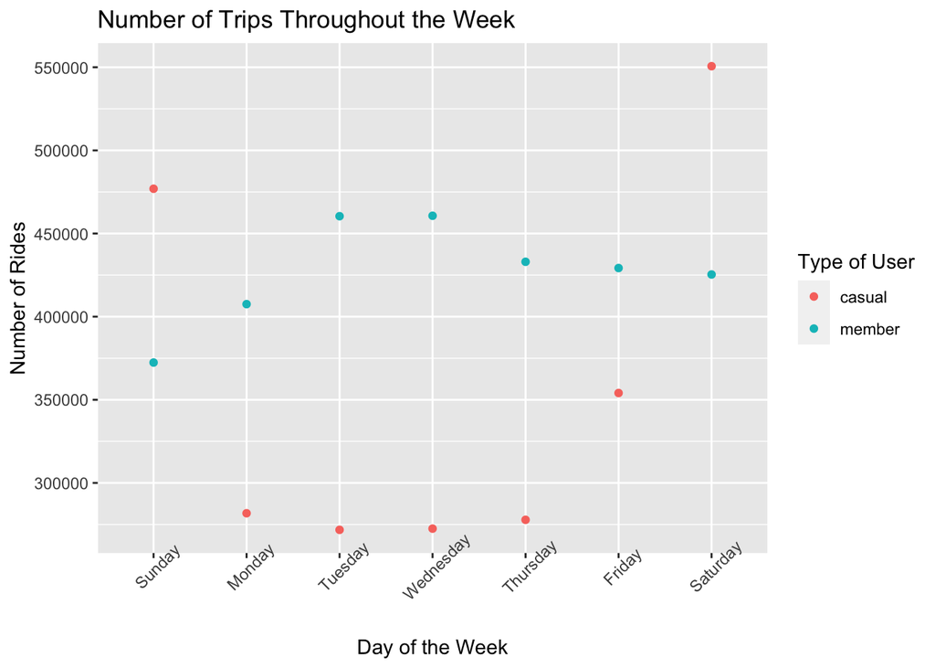

```r
all_trips_2 %>%
  group_by(membership, day_of_week) %>%
  summarize(min = min (trip_length), mean = mean(trip_length), median = median(trip_length), max = max(trip_length), number_of_rides = n()) %>%
ggplot(aes(x=day_of_week, y=number_of_rides)) + geom_point(mapping=aes(color=membership)) + labs(y="Number of Rides", x="Day of the Week", title="Number of Trips Throughout the Week", color="Type of User") + theme(axis.text.x = element_text(angle = 45))
```

```r
ggsave("NumberofTripsThroughoutWeek.png")
```

So we see that casual users definitely use the service differently than members.

Let’s also plot out average lengths of trips.

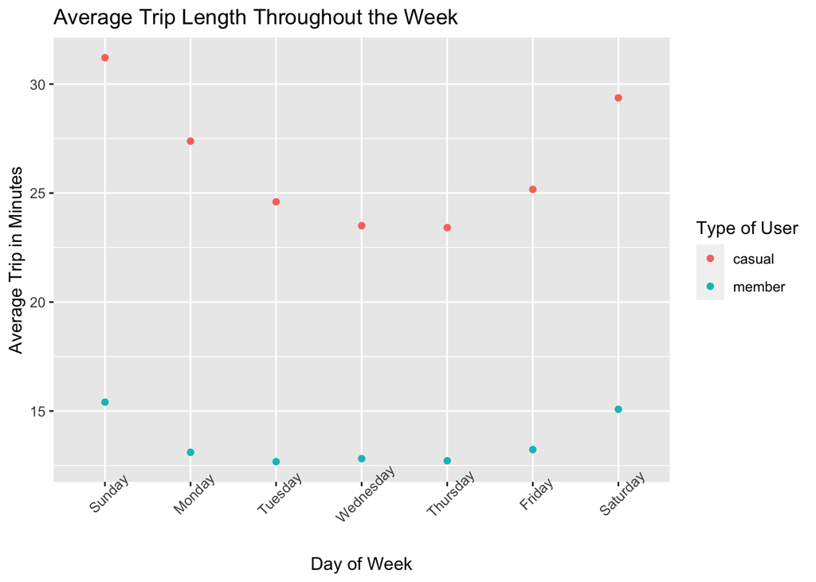

```r
all_trips_2 %>%
  group_by(membership, day_of_week) %>%
  summarize(mean_trip = mean(trip_length)/60) %>%
  ggplot(aes(x=day_of_week, y=mean_trip)) + geom_point(mapping=aes(color=membership)) + labs(y = "Average Trip in Minutes", x = "Day of Week", color="Type of User", title="Average Trip Length Throughout the Week") + theme(axis.text.x = element_text(angle = 45))
```

```r
ggsave("AverageTripLengthThroughoutWeek.png")
```

We can see that casual users also tend to have much longer rides than members.

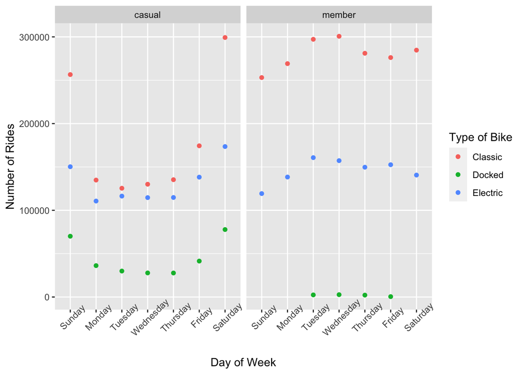

```r
all_trips_2 %>%
  group_by(membership, day_of_week, rideable_type) %>%
  summarize(number_of_rides = n()) %>%
ggplot(aes(x=day_of_week, y=number_of_rides)) + geom_point(mapping=aes(color=rideable_type)) + facet_wrap(~membership) + labs(x="Day of Week", y="Number of Rides") + scale_y_continuous(labels = function(x) format(x, scientific = FALSE)) + theme(axis.text.x = element_text(angle = 45)) + scale_color_discrete(name = "Type of Bike", labels = c("Classic", "Docked", "Electric"))
```

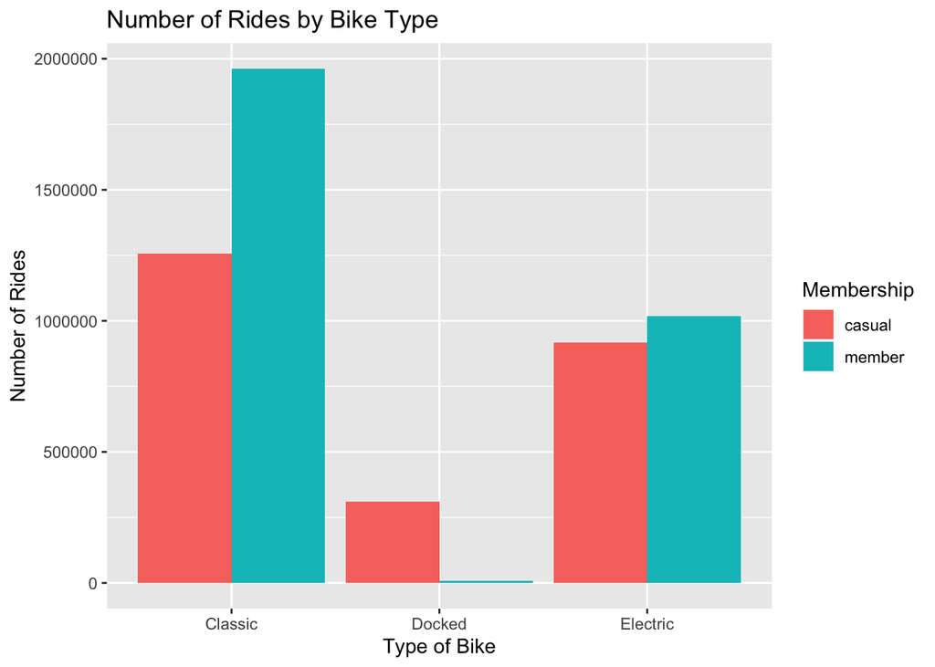

```r
all_trips_2 %>%
    group_by(rideable_type, membership) %>%
    summarize(number_of_rides = n()) %>%
    ggplot(aes(x=rideable_type, y=number_of_rides)) + geom_bar(aes(fill = membership), position = "dodge", stat="identity") + labs(x="Type of Bike", y="Number of Rides", title="Number of Rides by Bike Type",fill="Membership") + scale_x_discrete(labels=c("classic_bike" = "Classic", "docked_bike" = "Docked", "electric_bike" = "Electric"))
```

Here we see that casual users are also less likely to use the classic bike offering and far more likely to use the docked bike option.

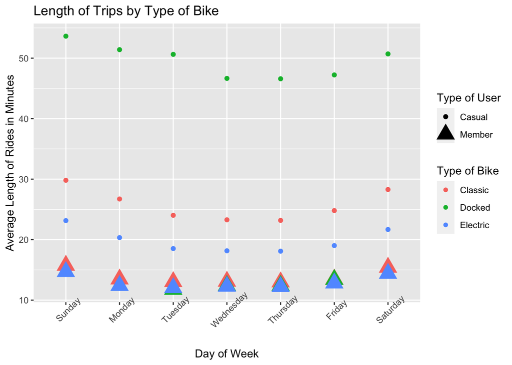

```r
all_trips_2 %>%
  group_by(membership, day_of_week, rideable_type) %>%
  summarize(number_of_rides = n(), mean_length = mean(trip_length)/60) %>%
ggplot(aes(x=day_of_week, y=mean_length)) + geom_point(mapping=aes(color=rideable_type, shape=membership, size=membership)) + labs(x="Day of Week", y="Average Length of Rides in Minutes", title="Length of Trips by Type of Bike") + scale_y_continuous(labels = function(x) format(x, scientific = FALSE)) + theme(axis.text.x = element_text(angle = 45)) + scale_color_discrete(name = "Type of Bike", labels = c("Classic", "Docked", "Electric")) + scale_shape_discrete(name = "Type of User", labels = c("Casual", "Member")) + scale_size_discrete(name = "Type of User", labels = c("Casual", "Member"))
```

```r
ggsave("LengthofTripbyBike.png")
```

Here we see emphasis that casual users have longer trips than members in general. We also see that casual users have their longest trips on the docked bikes.

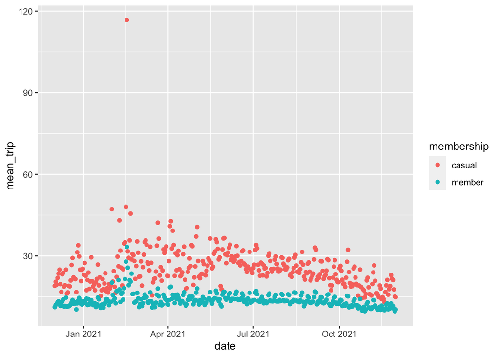

```r
all_trips_2 %>%
  group_by(membership, date) %>%
  summarize(mean_trip = mean(trip_length)/60, number_of_rides = n()) %>%
ggplot(aes(x=date, y=mean_trip)) + geom_point(mapping=aes(color=membership))
```

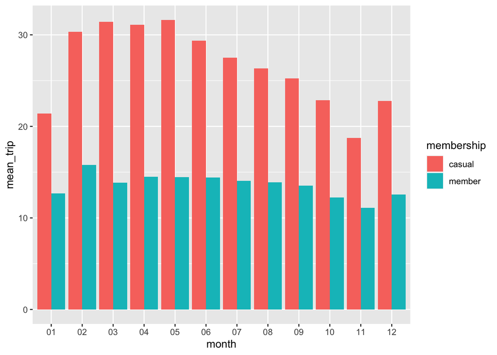

```r
all_trips_2 %>%
  group_by(month, membership) %>%
  summarize(number_of_rides = n(), mean_trip=mean(trip_length)/60) %>%
ggplot(aes(x=month, y=mean_trip)) + geom_bar(aes(fill = membership), position = "dodge", stat="identity")
```

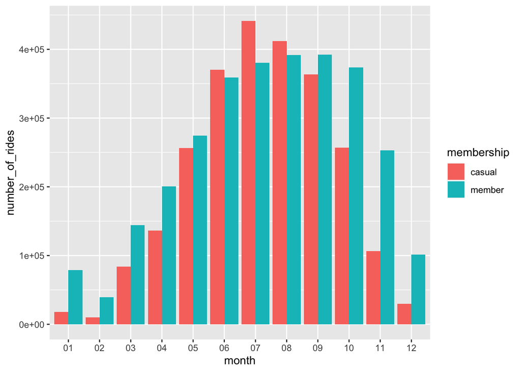

```r
all_trips_2 %>%
  group_by(month, membership) %>%
  summarize(number_of_rides = n()) %>%
ggplot(aes(x=month, y=number_of_rides)) + geom_bar(aes(fill = membership), position = "dodge", stat="identity")
```